# Add a Forest Plot Column to a gtsummary Table

Source: [`R/add_forest.R`](https://github.com/insightsengineering/crane/blob/main/R/add_forest.R)

This function adds a forest plot column to a gtsummary table, typically produced by `tbl_roche_subgroups()`. The forest plot visualizes estimates and confidence intervals for each subgroup in the table. The function supports rendering with either the `gt` or `flextable` engines, making it suitable for different outputs.

```r
add_forest(
  x,
  estimate = starts_with("estimate"),
  conf_low = starts_with("conf.low"),
  conf_high = starts_with("conf.high"),
  pvalue = starts_with("p.value"),
  after = starts_with("p.value"),
  header_spaces = 20,
  table_engine = c("flextable", "gt")
)
```

## Arguments

**x**

(`gtsummary`)  
A gtsummary table with estimates and confidence intervals in the table body. Usually produced by `tbl_roche_subgroups()`.

**estimate**

(`tidy-select`)  
Estimate column name.

**conf_low**

(`tidy-select`)  
Confidence interval lower bound column name.

**conf_high**

(`tidy-select`)  
Confidence interval upper bound column name.

**pvalue**

**after**

(`tidy-select`)  
Column name after which the forest plot column will be added. Default is after the p-value column.

**header_spaces**

(`integer`)  
Spaces to add to the forest plot header to visually separate the two treatment areas (`trt A\n Better` and `trt B\nBetter`). It is suggested to modify manually this variable if the treatment names are long, with `add_forest(..., header_spaces = 5)` or `flextable::set_header_labels(ggplot = "*")`.

**table_engine**

(`character`)  
Table rendering engine to use. Default is "flextable".

## Value

a gt table or flextable object with an added forest plot column.

## Details

Both gt and flextable outputs could produce issues in line continuity between rows if there are wrapping in the statistical cells.

## Examples

```r
# Simple example ------------------------------------------------------------
trial |>
  select(age, marker, grade, response) |>
  tbl_uvregression(
    y = response,
    method = glm,
    method.args = list(family = binomial),
    exponentiate = TRUE,
    hide_n = TRUE
  ) |>
  modify_column_merge(
    pattern = "{estimate} (95% CI {ci}; {p.value})",
    rows = !is.na(estimate)
  ) |>
  modify_header(estimate = "**Odds Ratio**") |>
  add_forest(table_engine = "gt")
```

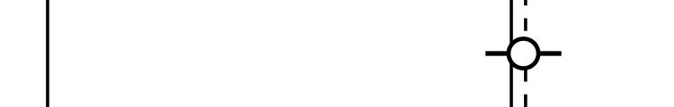

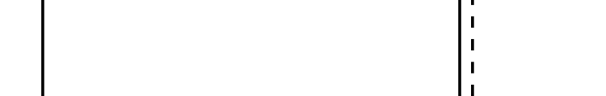

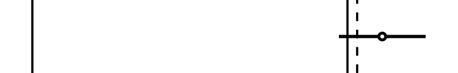

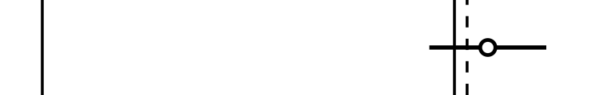

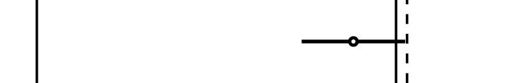

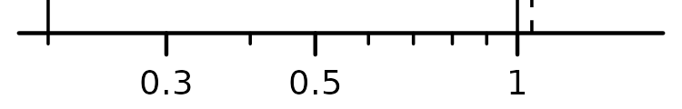

```r
  Characteristic
      Odds Ratio
      95% CI

    Age
1.02 (95% CI 1.00,  1.04; 0.10)
1.00, 1.04
Marker Level (ng/mL)
1.35 (95% CI 0.94,  1.93; 0.10)
0.94, 1.93
Grade




    I
—
—
    II
0.95 (95% CI 0.45,  2.00; 0.9)
0.45, 2.00
    III
1.10 (95% CI 0.52,  2.29; 0.8)
0.52, 2.29






Abbreviations: CI = Confidence Interval, OR = Odds Ratio

# Realistic example ---------------------------------------------------------
# \donttest{
if (requireNamespace("broom.helpers", quietly = TRUE)) {
  trial |>
    tbl_roche_subgroups(
      rsp = "response",
      by = "trt",
      subgroups = c("grade"),
      ~ glm(response ~ trt, data = .x) |>
        gtsummary::tbl_regression(
          show_single_row = trt,
          exponentiate = TRUE # , tidy_fun = broom.helpers::tidy_parameters
        )
    ) |>
    add_forest(pvalue = starts_with("p.value"), table_engine = "flextable") |>
    flextable::set_header_labels(ggplot = "---------")
}
 Drug ADrug B Baseline Risk FactorsTotal nn Response (%)n Response (%)estimate95% CIp-value---------All Participants19395 (29.5 %)98 (33.7 %)1.040.91, 1.190.5GradeI6735 (22.9 %)32 (40.6 %)1.190.96, 1.490.12II6330 (23.3 %)33 (36.4 %)1.140.91, 1.430.3III6330 (43.3 %)33 (24.2 %)0.830.66, 1.040.11# }
```